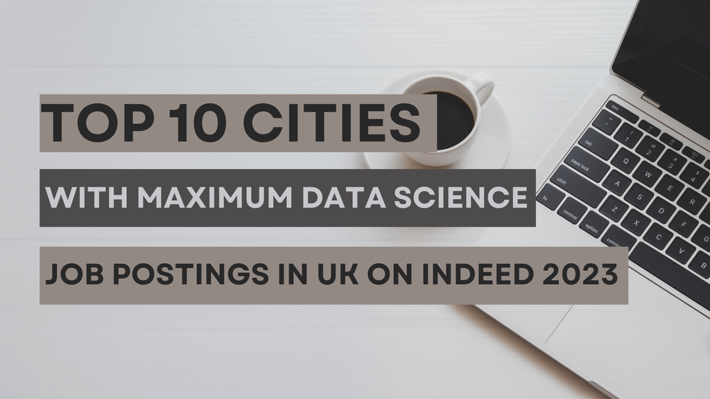

# **Where to Look for Your Next Data Science Job : Charting 2023's Top 10 Cities in UK**

**Introduction**

The data science industry has proliferated in the last several years, and there doesn't appear to be a slowing in sight. Data scientists are in greater demand than ever as businesses look to extract value from their data assets. As per [(Davenport and Patil)](https://hbr.org/2022/07/is-data-scientist-still-the-sexiest-job-of-the-21st-century) data science experts in the UK are looking to take advantage of this rapidly evolving field, offers fantastic employment chances.

However, the distribution of the growing number of data science positions is uneven. A few cities have become epicenters ready to maintain their dominance in this field. Thus, in 2023, which major geographic centers will be offering chances in data science? This data visualization blog post ranks the top 10 UK cities with the most open data science positions listed using real-time job posting analytics and core data science methodologies. By extracting and analyzing hiring demand data, the visualization produces clear locations of data science job prospects as of 2023. The flow of this blog includes the complete process of how the data was collected, processed, and visualized. The blog uses various libraries in Python and supports understanding the target cities for the Data Science Job role.

**Aim and Objective**

This blog aims to present the analysis of the top 10 cities of Data Science Job postings in the UK posted on Indeed in 2023. The objective is to shed light on the top 10 UK locations with the highest number of data science job posts in 2023 by utilizing data science competencies such as keyword analysis and information design with the help of data visualization.

**Methodology**

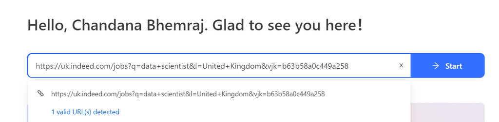

*2. Data Preprocessing* : It is important to preprocess that data before it is used for analysis, So data cleaning was done by removing the duplicates which was a default option from the Octoparse tool. After exporting the file into CSV, I pre-processed the data to remove rows with no location and have replaced the "Remote in London" location column with "London" because the major aim is to find the max postings in the city and not on Remote or on-site jobs. Thus the final CSV file that will be used for further Data analysis is "Final Data Scientist Jobs in United Kingdom - 2023 _ Indeed.com.csv". The below code shows the pre-processed data after all the data cleaning activities. The final data printed just has 3 columns with the Company name , Job title, and location. Rest all the scraped data is removed as it was not related information for the aim of this blog.

```python
#Importing all the required librieres to run the below code
import pandas as pd
import matplotlib.pyplot as plt #(“Python Data Analysis with Pandas and Matplotlib”)

# Creating a dataframe by reading the csv file onto it using pandas
df = pd.read_csv('/content/Final Data Scientist Jobs in United Kingdom - 2023 _ Indeed.com.csv')
# Printing the dataframe created , data printed is pre-processed
df.head()
```

|  | Company | Job Title | Location |
| --- | --- | --- | --- |
| 0 | Forest Green Rovers Football Club | Data Scientist | Nailsworth |
| 1 | Multiverse | Data Science Instructor, UK | Manchester |
| 2 | CERN | STEM internships (engineering, data science, I... | Bristol |
| 3 | Kortext | Higher Education Technology DevOps Engineer | Manchester |
| 4 | Hertz Europe | Revenue Management Data Science Analytics Engi... | Uxbridge |

```python
# Converting all city names to lowercase to ensure consistency
df['Location'] = df['Location'].str.lower()

# Group by city and count the number of job postings
city_job_counts = df.groupby('Location').size().sort_values(ascending=False)
print(city_job_counts)
# Select the top 10 cities
top_cities = city_job_counts.head(100).index.tolist()

# Filter the DataFrame for the top 10 cities
df_top_cities = df[df['Location'].isin(top_cities)]

# Combine job descriptions for the top 10 cities
combined_text = ' '.join(df_top_cities['Location'])
```

```
Location
london                447
manchester             78
cambridge              35
bristol                17
oxford                 14
                     ...
greater manchester      1
gloucester              1
gibraltar               1
gaydon                  1
york                    1
Length: 136, dtype: int64
```

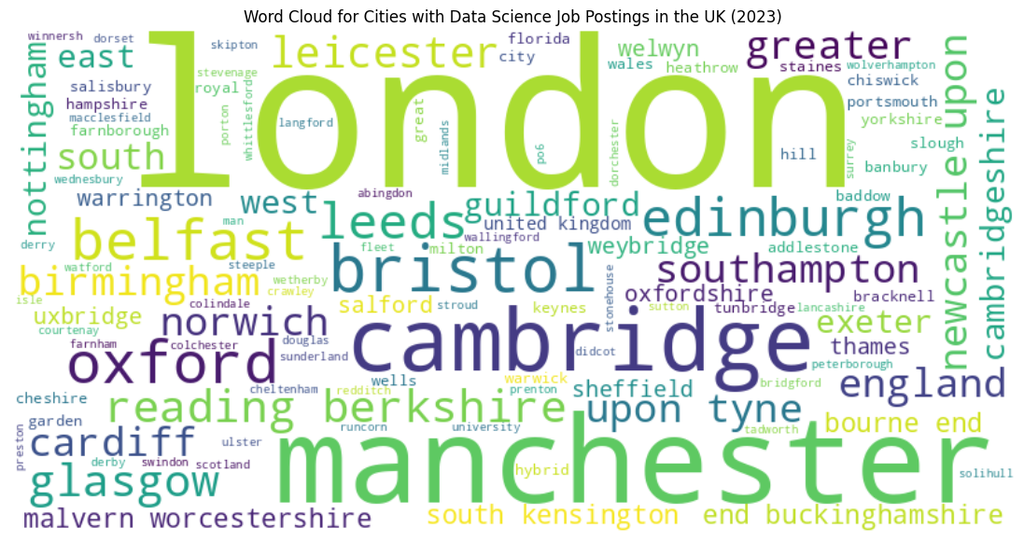

```python
# To visualize the top 10 cities in a creative way , I have Generated the word cloud
from wordcloud import WordCloud
wordcloud = WordCloud(width=800, height=400, background_color='white').generate(combined_text)

# Display the word cloud
plt.figure(figsize=(20, 7))
plt.imshow(wordcloud, interpolation='bilinear')
plt.axis('off')
plt.title('Word Cloud for Cities with Data Science Job Postings in the UK (2023)')
plt.show()
```

**5. Data Interpretation**: An understandable overview of the concentrated areas of demand for data science jobs in the UK is shown by the combo data visualization. Understanding the importance of the cities in the word cloud provides first indications about the best places with the most vacancies in the developing field. Candidates looking for jobs in data science have a plethora of options because of London's dominant and audacious presence. In the meantime, secondary centers such as Manchester and Cambridge also appear in extensive literature. The word cloud illustrates the topography of the areas where employment with expertise is concentrated.

Data-driven insights grow increasingly accurate as they go to a bar chart. The spectacular blue tower symbolizing London may be statistically contrasted with smaller bars representing other cities to show the enormous volume disparity. The word cloud indicates that London is first, but the bar graph specifies how much. Some noteworthy conclusions also jump out. Thus readers can develop trustworthy interpretations based on text size and bar length. The visually appealing and simple depiction, as opposed to tables of numbers, enables quick analysis of the locations where data scientists have the most employment prospects based on actual recruiting activity.

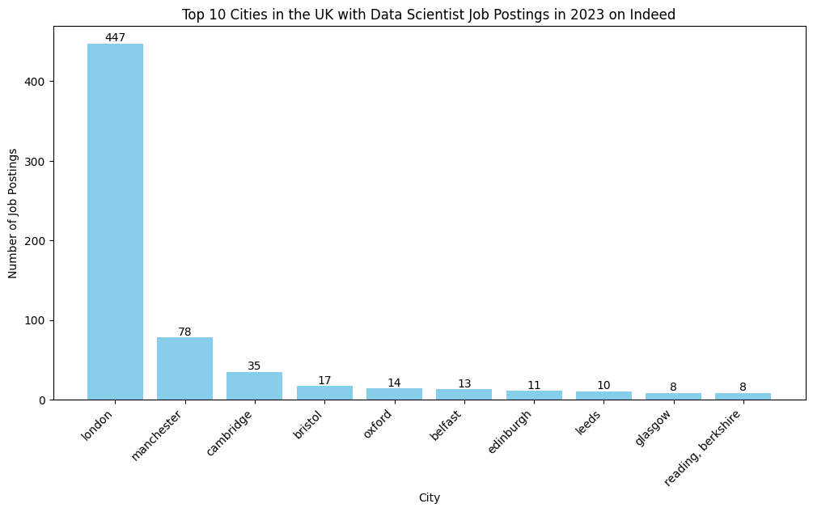

```python
# Select the top 10 cities
top_cities = city_job_counts.head(10).index.tolist()

# Filter the DataFrame for the top 10 cities
df_top_cities = df[df['Location'].isin(top_cities)]

# Plotting the bar graph
plt.figure(figsize=(12, 6))
bars = plt.bar(top_cities, city_job_counts.head(10), color='skyblue')

# Adding labels on each bar
for bar in bars:
    yval = bar.get_height()
    plt.text(bar.get_x() + bar.get_width()/2, yval, round(yval, 2), ha='center', va='bottom')

# Adding title and labels
plt.title('Top 10 Cities in the UK with Data Scientist Job Postings in 2023 on Indeed')
plt.xlabel('City')
plt.ylabel('Number of Job Postings')
plt.xticks(rotation=45, ha='right')
plt.show()
```

**Related Work**

According to research in 2019,[(“UK Data Science & Analytics Job Market in 2019”)](https://www.datacareer.co.uk/blog/uk-data-science-analytics-job-market-in-2019/#:~:text=The%20most%20popular%20UK%20cities,and%20Cambridge%20definitely%20stand%20out).,The top cities for the Data Science job market were London, Cambridge, Edinburgh, and Manchester. If we look into the current Top cities there are no major changes in the city list but the order has certain changes which talk about the high growing demand for data science job roles in the city like Manchester as it has a positive trajectory compared to 2019 (Figure 1) it was at top 4 and according to my research it’s at top 2. Hence candidates like me who are hunting for Data Scientist roles can look forward to such on-demand cites for their data science careers. As per [(DATA SCIENCE in the UK SALARY SURVEY & POST COVID-19 IMPACT Career Paths.)](https://www.cornucopiaitr.com/download_files/Salary-Survey-Data-Scientist-Report2.pdf) While the UK economy has been severely impacted by the COVID-19 epidemic, particularly the Data Science employment market, it is crucial to remember that the loss has only been shown in terms of salary growth with the number of job vacancies witnessing a reasonable growth year over year

Regarding pay growth, there has been a reasonable yearly increase in the number of employment openings. One of the most lucrative IT disciplines is still data science, where professionals with intermediate skill and experience levels can make up to £50,000.

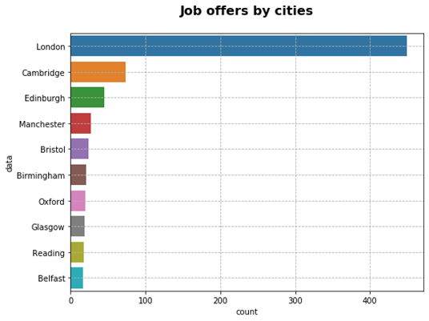

**Figure 1: Data Science Job Market in 2019** [(“UK Data Science & Analytics Job Market in 2019”)](https://www.datacareer.co.uk/blog/uk-data-science-analytics-job-market-in-2019/#:~:text=The%20most%20popular%20UK%20cities,and%20Cambridge%20definitely%20stand%20out).

**Conclusion**

Few IT jobs provide the potential for data science to develop and become more exciting in the years to come, even as data continues to be the catalyst for innovation across sectors. This data visualization blog article highlights the best places to start or grow a data science career in 2023 based on the number of available employment, for anyone hoping to ride this wave in the UK.

It is simple to identify UK hubs that are now dominating the market in data science employment possibilities the word cloud and bar graph combination has helped me to provide a better insight. Unsurprisingly, due to sheer demand, bustling London comes in first place on the list by a significant amount. However, the image also shows developing secondary locations like Manchester, Cambridge, and Bristol that have burgeoning data science industries.

I set out to find the best locations in the UK with the most active job market as a master's student studying data science to start my career in the field. I collected, analyzed, and produced a visual representation of the patterns in data science job postings across UK cities in 2023 using data analytics principles such as web scraping and visual data storytelling that I had studied in my coursework. In addition to emerging cities like Manchester and Cambridge, where competition for aspiring data specialists may be less fierce, this practical experiment identified London as the primary hub. Through proactive use of my evolving data science abilities to interpret the UK employment market, I can now narrow my search to UK cities with positions that suit my qualifications.

**References**

- Davenport, Thomas H., and D. J. Patil. “Is Data Scientist Still the Sexiest Job of the 21st Century?” Harvard Business Review, 15 July 2022, hbr.org/2022/07/is-data-scientist-still-the-sexiest-job-of-the-21st-century. :https://hbr.org/2022/07/is-data-scientist-still-the-sexiest-job-of-the-21st-century Accessed 11 Dec. 2023.
- “UK Data Science & Analytics Job Market in 2019.” Datacareer.co.uk, https://www.datacareer.co.uk/blog/uk-data-science-analytics-job-market-in-2019/#:~:text=The%20most%20popular%20UK%20cities,and%20Cambridge%20definitely%20stand%20out . Accessed 11 Dec. 2023.
- “Python Data Analysis with Pandas and Matplotlib.” https://ourcodingclub.github.io/tutorials/pandas-python-intro/. Accessed 13 Dec. 2023.
- DATA SCIENCE in the UK SALARY SURVEY & POST COVID-19 IMPACT Career Paths. https://www.cornucopiaitr.com/download_files/Salary-Survey-Data-Scientist-Report2.pdf Accessed 13 Dec. 2023
- “Word Cloud in Python | Create a Customized Word Cloud.” Analytics Vidhya, 15 Aug. 2021, https://www.analyticsvidhya.com/blog/2021/08/creating-customized-word-cloud-in-python/. Accessed 13 Dec. 2023.

**Appendix**

1. Link used for scraping : https://uk.indeed.com/jobs?q=data+scientist&l=United+Kingdom&vjk=5b50fa36c67f770b
2. Tool used for scraping: https://www.octoparse.com/
3. The Cover image to this blog is designed by me on Canva and hence it is not referenced.
4. Code syntax refered by : https://www.w3schools.com/python/numpy/default.asp
5. Code error cleared by referencing: https://stackoverflow.com/